# Text Mining with Sentiments

Tiffany Gonzalez

2017-11-14

To get our data cleaned up and ready to work with sentiments, we will do the following:

```r
#Dracula is number 345 in the gutenbergr database
dracula<-gutenberg_download(345)
```

```
## Determining mirror for Project Gutenberg from http://www.gutenberg.org/robot/harvest
```

```
## Using mirror http://aleph.gutenberg.org
```

```r
# Strip each word from the text
dracula_words<-dracula%>%
  unnest_tokens(word,text)

#The gutenberg id column is unnecessary, so remove it
dracula_words$gutenberg_id<-NULL
```

Bing is a sentiment set that provides a list of words and classifies each word as positive, or negative. Let’s first bring ‘bing’ to a data frame and inner join the words and bing, as to classify each word:

```r
bing<-get_sentiments('bing')

dracula_words<-inner_join(dracula_words,bing)
dracula_words
```

```
## # A tibble: 10,046 x 2
##         word sentiment
##        <chr>     <chr>
##  1       beg  negative
##  2 wonderful  positive
##  3   correct  positive
##  4  splendid  positive
##  5     noble  positive
##  6    pretty  positive
##  7      good  positive
##  8      good  positive
##  9    useful  positive
## 10    struck  negative
## # ... with 10,036 more rows
```

## Positive Sentiments

Let’s first build a graph based on only the positive sentiment words:

```r
dracula_pos<-dracula_words%>%
  filter(sentiment=='positive')%>%
  group_by(word)%>%
  summarize(count=n(),sentiment=first(sentiment))%>% #groups each word, which is positive (sentiment), creates 3 columns
  arrange(count)%>%
  top_n(10, wt=count)   # return top 10 records according to some column, in this case, count column

dracula_pos
```

```
## # A tibble: 10 x 3
##      word count sentiment
##     <chr> <int>     <chr>
##  1  sweet    66  positive
##  2  ready    71  positive
##  3 better    77  positive
##  4   love    84  positive
##  5  right    99  positive
##  6   work   146  positive
##  7  great   183  positive
##  8   well   245  positive
##  9   good   258  positive
## 10   like   292  positive
```

We then want to classify each word in the ‘word’ column as a factor, not a character and store it back into the data frame we have been working with..

```r
class(dracula_pos$word)
```

```
## [1] "character"
```

```r
dracula_pos$word<-factor(dracula_pos$word,levels=dracula_pos$word)
```

Finally, we will graph our positive sentiments

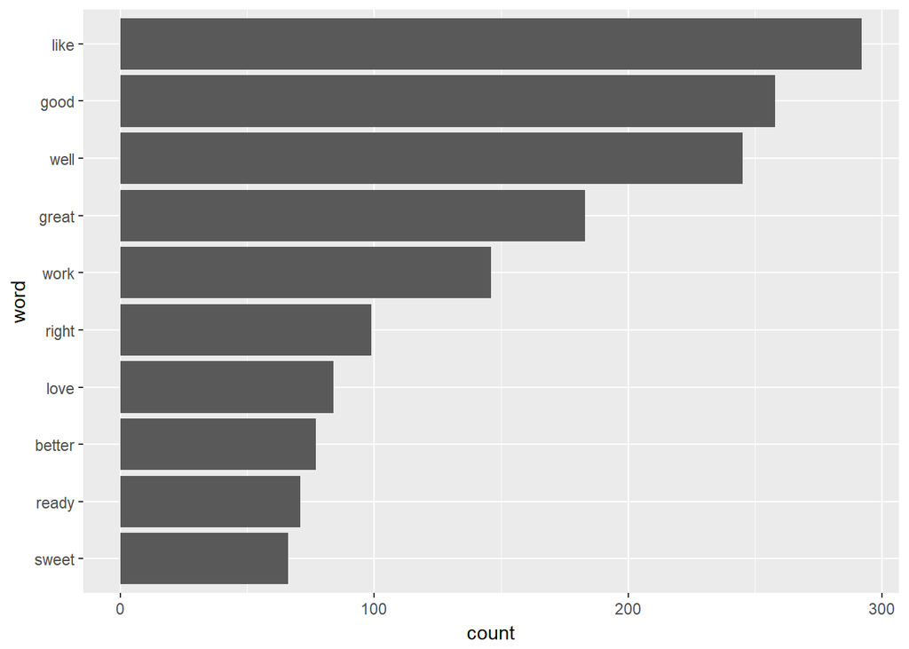

```r
ggplot()+
  geom_bar(data=dracula_pos,aes(x=word,y=count),stat='identity')+
  coord_flip()
```

## Negative Sentiments

We will now use the same code as above, but using the negative words. We won’t include the word ‘miss’ , because that is not used as a negative word but rather a prefix to a name.

```r
dracula_neg<-dracula_words%>%
  filter(sentiment=='negative')%>%
  group_by(word)%>%
  summarize(count=n(),sentiment=first(sentiment))%>%
  arrange(count)%>%
  filter(word != 'miss')%>%
  top_n(10, wt=count)

tail(dracula_neg, n=20)
```

```
## # A tibble: 10 x 3
##        word count sentiment
##       <chr> <int>     <chr>
##  1     hard    49  negative
##  2  trouble    53  negative
##  3     fell    59  negative
##  4     dark    77  negative
##  5  strange    90  negative
##  6    death    94  negative
##  7 terrible   100  negative
##  8     dead   109  negative
##  9     fear   137  negative
## 10     poor   193  negative
```

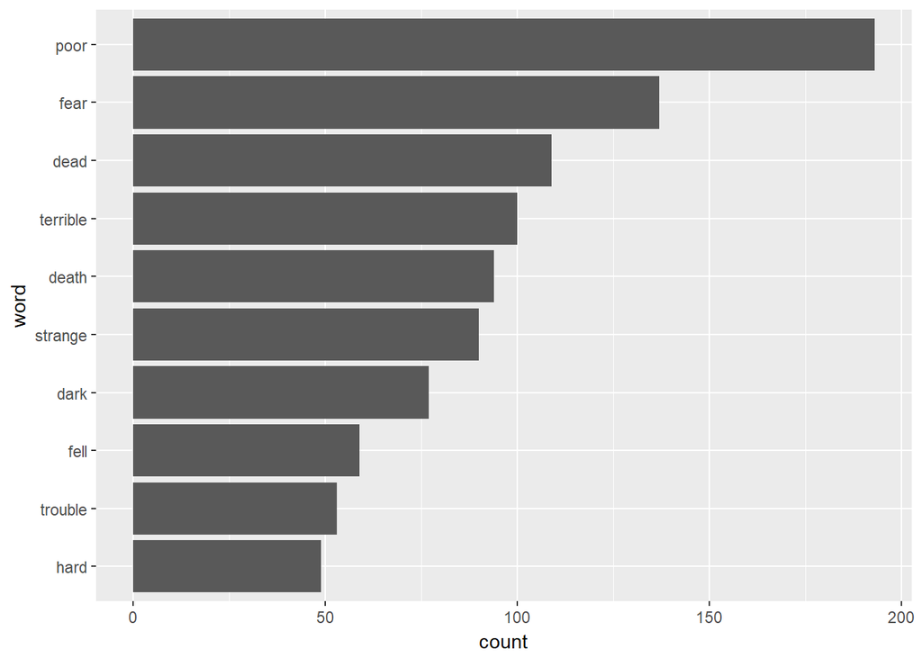

```r
dracula_neg$word<-factor(dracula_neg$word,levels=dracula_neg$word)

ggplot()+
  geom_bar(data=dracula_neg,aes(x=word,y=count),stat='identity')+
  coord_flip()
```

Now we are ready to combine the graphs into 1.

```r
dracula_comp<-rbind(dracula_pos, dracula_neg) #rbind allows you to put one graph on top of other.. You can still see which words are positive and negative
```

And time to plot!

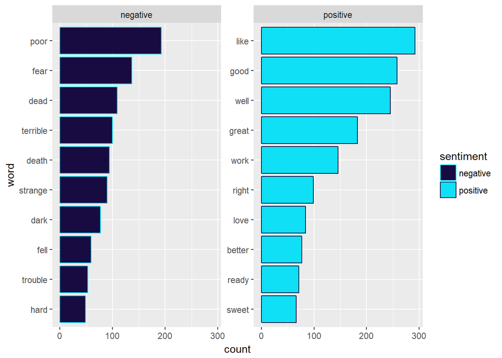

```r
ggplot()+
  geom_bar(data=dracula_comp,aes(x=word,y=count, fill=sentiment, color = sentiment),stat='identity')+
  facet_wrap(~sentiment, scales = 'free_y')+      #what column disinguishes the 2 groups...in this case, the sentiment column
  coord_flip()+                                       #scales = 'free_y' -> splits the y axis into the correct graph
  scale_fill_manual(values=c('#170b42','#10e0f5'))+   #first # is negative color, second is positive
  scale_color_manual(values=c('#10e0f5','#170b42'))
```